# Visualizing data with ggplot2

Aaron A. King

09/21/2014

In this document, we’ll practice visualizing data using *ggplot2*.

### Loading packages and data

First, we’ll load some packages. If the following generates an error, you may need to install these packages.

```r
require(ggplot2)
require(plyr)
require(reshape2)
```

Now, we’ll load some data.

```r
course.url <- "http://kinglab.eeb.lsa.umich.edu/480"
datafile <- paste(course.url,"data/seedpred.csv",sep='/')
dat <- read.csv(datafile,comment.char="#",
                colClasses=c(species='factor',dist='factor',date="Date"))
sapply(dat,class)
```

```
##   station      dist   species      date     seeds
## "integer"  "factor"  "factor"    "Date" "integer"
```

```r
head(dat)
```

```
##   station dist species       date seeds
## 1       1   10     psd 1999-03-25     5
## 2       1   10     psd 1999-03-28     5
## 3       1   10     psd 1999-04-04     5
## 4       1   10     psd 1999-04-11     5
## 5       1   10     psd 1999-04-18     0
## 6       1   10     psd 1999-04-25     0
```

Note, it was useful to me to first run `file.show()` on the data file, to read the comments there. These are just the raw data from the seed-predation component of the study by [Duncan and Duncan (2000)](http://dx.doi.org/10.1111/j.1744-7429.2000.tb00445.x).

### Examining the data.

Number of species, stations, and distances; also, number of distances per station, species per station, and stations per species/distance pair:

```r
summarize(dat,
          nspp=length(unique(species)),
          nsta=length(unique(station)),
          ndist=length(unique(dist))
          )
```

```
##   nspp nsta ndist
## 1    8  158     2
```

```r
ddply(dat,~station,summarize,nspp=length(unique(species)),ndist=length(unique(dist)))
```

```
##     station nspp ndist
## 1         1    1     2
## 2         2    1     2
## 3         3    1     2
## 4         4    1     2
## 5         5    1     2
## 6         6    1     2
## 7         7    1     2
## 8         8    1     1
## 9         9    1     2
## 10       10    1     2
## 11       11    1     1
## 12       12    1     2
## 13       13    1     2
## 14       14    1     2
```

[output cut: 144 more lines]

```r
daply(dat,~species+dist,summarize,nsta=length(unique(station)))
```

```
##        dist
## species 10 25
##     abz 18 19
##     cd  16 16
##     cor 20 20
##     dio 20 20
##     mmu 17 20
##     pol 12 19
##     psd 19 18
##     uva 20 20
```

Let us plot some typical replicates.

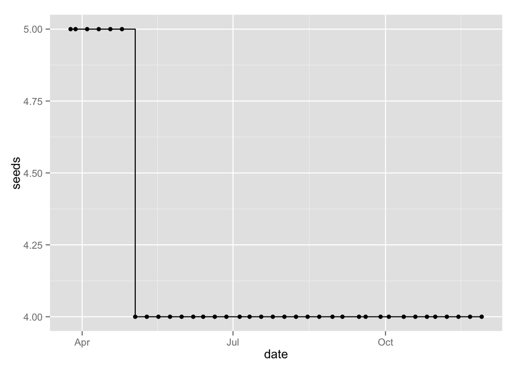

```r
x <- subset(dat,station==17 & dist==10)
ggplot(data=x,mapping=aes(x=date,y=seeds))+geom_point()+geom_step()
```

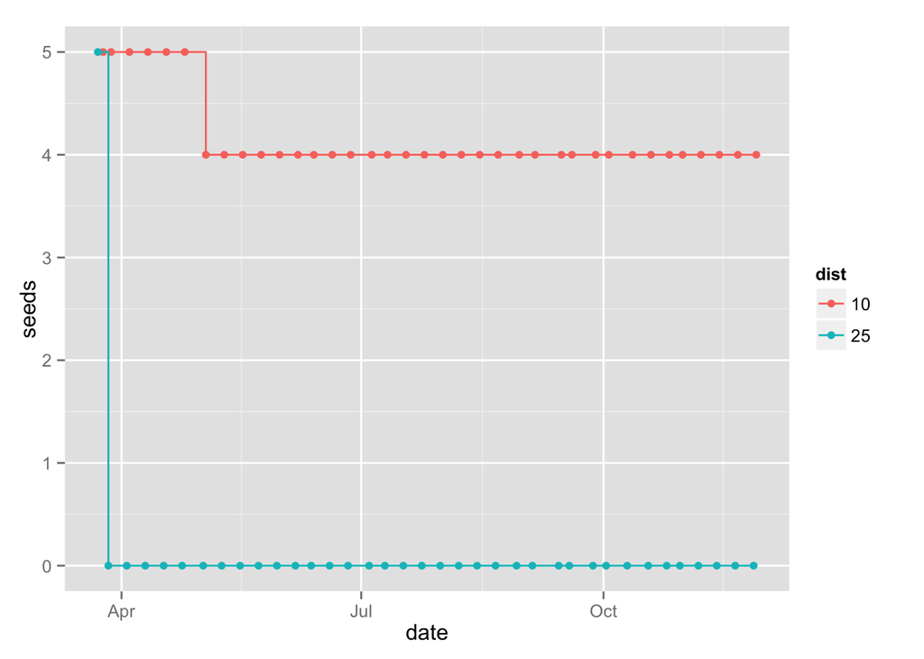

```r
ggplot(data=subset(dat,station==17),mapping=aes(x=date,y=seeds,group=dist,color=dist))+geom_point()+geom_step()
```

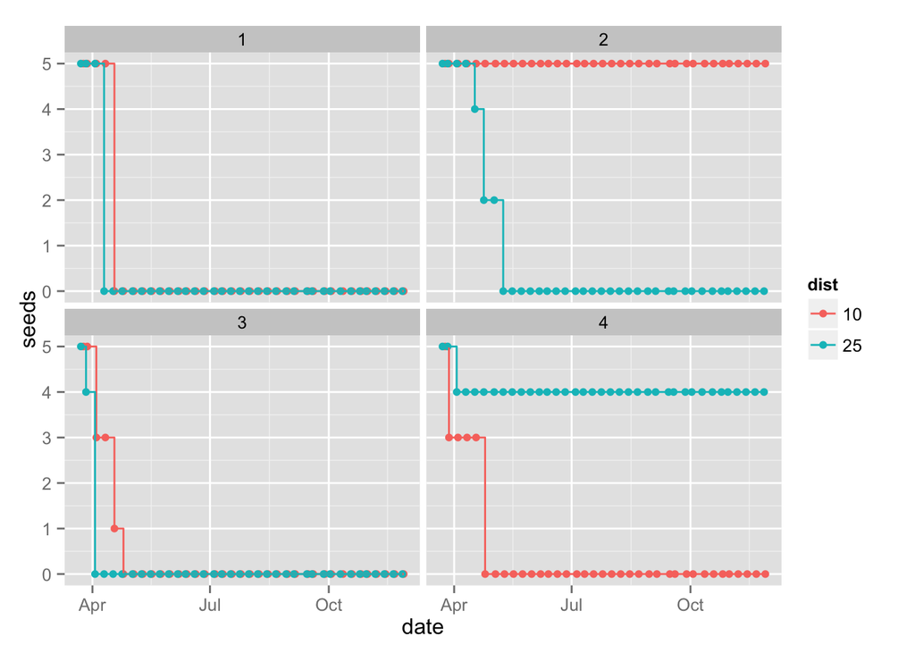

```r
ggplot(data=subset(dat,station %in% 1:4),mapping=aes(x=date,y=seeds,group=dist,color=dist))+
  geom_point()+geom_step()+facet_wrap(~station)
```

### Estimating rates

Extracting time to removal of all seeds. First, exclude replicates for which either no seeds were laid out or not all seeds were taken:

```r
ddply(dat,~station+dist+species,subset,max(seeds)>0 & min(seeds)==0) -> dat1
```

Now, we want to consider that the time after there were no seeds present contributes no information about the seed predation process. So, we should eliminate those observations:

```r
ddply(dat1,~station+dist+species,mutate,avail=c(NA,head(seeds,-1))) -> dat1
ddply(dat1,~station+dist+species,subset,is.na(avail) | avail>0) -> dat2
```

Now, we want to know how many seeds were taken at each station/dist/species combination and how long it took:

```r
ddply(dat2,~station+dist+species,summarize,
      max(seeds),
      min(seeds),
      taken=max(seeds)-min(seeds),
      time=diff(range(date)),
      rate=taken/as.numeric(time)
      ) -> dat2
head(dat2)
```

```
##   station dist species ..1 ..2 taken    time   rate
## 1       1   10     psd   5   0     5 24 days 0.2083
## 2       1   25     psd   5   0     5 18 days 0.2778
## 3       2   25     uva   5   0     5 47 days 0.1064
## 4       3   10     pol   5   0     5 31 days 0.1613
## 5       3   25     pol   5   0     5 11 days 0.4545
## 6       4   10     dio   5   0     5 31 days 0.1613
```

Note that the units of the `rate` variable are seeds/day. Now we can summarize these rates across replicates:

```r
ddply(dat2,~species+dist,summarize,
      meanRate=mean(rate),
      sdRate=sd(rate),
      semRate=sdRate/sqrt(length(rate))
      )
```

```
##    species dist meanRate sdRate semRate
## 1      abz   10   0.6548 0.5627 0.15039
## 2      abz   25   0.4948 0.4141 0.10693
## 3       cd   10   0.6005 0.5301 0.13687
## 4       cd   25   0.6654 0.4925 0.13659
## 5      cor   10   0.5613 0.6015 0.19021
## 6      cor   25   0.2236 0.1996 0.06313
## 7      dio   10   0.6709 0.6926 0.20883
## 8      dio   25   0.4112 0.4116 0.11416
## 9      mmu   10   0.8343 0.6694 0.20182
## 10     mmu   25   0.5323 0.4429 0.11073
## 11     pol   10   0.6128 0.6683 0.21135
## 12     pol   25   0.4269 0.4447 0.10482
## 13     psd   10   0.2229 0.1383 0.04611
## 14     psd   25   0.4815 0.4278 0.13529
## 15     uva   10   0.4013 0.5342 0.18887
## 16     uva   25   0.2701 0.3369 0.09005
```

Alternatively,

```r
daply(dat2,~species+dist,summarize,
      meanRate=mean(rate),
      sdRate=sd(rate),
      semRate=sdRate/sqrt(length(rate))
      )
```

```
## , ,  = meanRate
##
##        dist
## species 10     25
##     abz 0.6548 0.4948
##     cd  0.6005 0.6654
##     cor 0.5613 0.2236
##     dio 0.6709 0.4112
##     mmu 0.8343 0.5323
##     pol 0.6128 0.4269
##     psd 0.2229 0.4815
##     uva 0.4013 0.2701
##
## , ,  = sdRate
##
##        dist
## species 10     25
##     abz 0.5627 0.4141
##     cd  0.5301 0.4925
##     cor 0.6015 0.1996
##     dio 0.6926 0.4116
##     mmu 0.6694 0.4429
##     pol 0.6683 0.4447
##     psd 0.1383 0.4278
##     uva 0.5342 0.3369
##
## , ,  = semRate
##
##        dist
## species 10      25
##     abz 0.1504  0.1069
##     cd  0.1369  0.1366
##     cor 0.1902  0.06313
##     dio 0.2088  0.1142
##     mmu 0.2018  0.1107
##     pol 0.2114  0.1048
##     psd 0.04611 0.1353
##     uva 0.1889  0.09005
```